# Lab 3 Report

Michael Egle michaelegle@iastate.edu, John Chandara chandara@iastate.edu

2/19/2020

```r
library(tidyverse)
library(ggtern)
install.packages('readxl')
library(readxl)
dat <- readxl::read_xls('GSS.xls')
str(dat)
```

```
## Classes 'tbl_df', 'tbl' and 'data.frame':    64814 obs. of  10 variables:
##  $ Gss year for this respondent: num  1972 1972 1972 1972 1972 ...
##  $ General happiness           : chr  "Not too happy" "Not too happy" "Pretty happy" "Not too happy" ...
##  $ Political party affiliation : chr  "Ind,near dem" "Not str democrat" "Independent" "Not str democrat" ...
##  $ Region of residence, age 16 : chr  "Middle atlantic" "E. nor. central" "E. nor. central" "Foreign" ...
##  $ Respondents sex             : chr  "Female" "Male" "Female" "Female" ...
##  $ Rs highest degree           : chr  "Bachelor" "Lt high school" "High school" "Bachelor" ...
##  $ Number of children          : chr  "0" "5" "4" "0" ...
##  $ Marital status              : chr  "Never married" "Married" "Married" "Married" ...
##  $ Respondent id number        : num  1 2 3 4 5 6 7 8 9 10 ...
##  $ Ballot used for interview   : chr  "Not applicable" "Not applicable" "Not applicable" "Not applicable" ...
```

# Data Cleaning

```r
indx <- sapply(dat, is.character)
dat[indx] <- lapply(dat[indx], function(x) as.factor(as.character(x)))
names(dat) <- c('year', 'happiness', 'party', 'residence', 'sex', 'education', 'children', 'marriage', 'id', 'ballot')
dat <- droplevels(dat[dat$happiness != 'No answer' & dat$happiness != 'Don\'t know' & dat$happiness != 'Not applicable', ])
dat <- droplevels(dat[dat$party != 'No answer', ])
dat$happiness <- factor(dat$happiness, c('Very happy', 'Pretty happy', 'Not too happy'))
str(dat)
```

```
## Classes 'tbl_df', 'tbl' and 'data.frame':    59709 obs. of  10 variables:
##  $ year     : num  1972 1972 1972 1972 1972 ...
##  $ happiness: Factor w/ 3 levels "Very happy","Pretty happy",..: 3 3 2 3 2 2 3 3 2 2 ...
##  $ party    : Factor w/ 9 levels "Don't know","Ind,near dem",..: 2 5 4 5 8 2 2 2 8 8 ...
##  $ residence: Factor w/ 10 levels "E. nor. central",..: 4 1 1 3 1 1 1 4 10 10 ...
##  $ sex      : Factor w/ 2 levels "Female","Male": 1 2 1 1 1 2 2 2 1 1 ...
##  $ education: Factor w/ 7 levels "Bachelor","Don't know",..: 1 6 4 1 4 4 4 1 4 4 ...
##  $ children : Factor w/ 10 levels "0","1","2","3",..: 1 6 5 1 3 1 3 1 3 5 ...
##  $ marriage : Factor w/ 6 levels "Divorced","Married",..: 3 2 2 2 2 3 1 3 3 2 ...
##  $ id       : num  1 2 3 4 5 6 7 8 9 10 ...
##  $ ballot   : Factor w/ 4 levels "Ballot a","Ballot b",..: 4 4 4 4 4 4 4 4 4 4 ...
```

```r
rotatedAxisElementText = function(angle,position='x'){
  angle     = angle[1];
  position  = position[1]
  positions = list(x=0,y=90,top=180,right=270)
  if(!position %in% names(positions))
    stop(sprintf("'position' must be one of [%s]",paste(names(positions),collapse=", ")),call.=FALSE)
  if(!is.numeric(angle))
    stop("'angle' must be numeric",call.=FALSE)
  rads  = (angle - positions[[ position ]])*pi/180
  hjust = 0.5*(1 - sin(rads))
  vjust = 0.5*(1 + cos(rads))
  element_text(angle=angle,vjust=vjust,hjust=hjust)
}
```

Now we have the string columns changed to factors.

```r
dat$children <- as.numeric(dat$children)
str(dat)
```

```
## Classes 'tbl_df', 'tbl' and 'data.frame':    59709 obs. of  10 variables:
##  $ year     : num  1972 1972 1972 1972 1972 ...
##  $ happiness: Factor w/ 3 levels "Very happy","Pretty happy",..: 3 3 2 3 2 2 3 3 2 2 ...
##  $ party    : Factor w/ 9 levels "Don't know","Ind,near dem",..: 2 5 4 5 8 2 2 2 8 8 ...
##  $ residence: Factor w/ 10 levels "E. nor. central",..: 4 1 1 3 1 1 1 4 10 10 ...
##  $ sex      : Factor w/ 2 levels "Female","Male": 1 2 1 1 1 2 2 2 1 1 ...
##  $ education: Factor w/ 7 levels "Bachelor","Don't know",..: 1 6 4 1 4 4 4 1 4 4 ...
##  $ children : num  1 6 5 1 3 1 3 1 3 5 ...
##  $ marriage : Factor w/ 6 levels "Divorced","Married",..: 3 2 2 2 2 3 1 3 3 2 ...
##  $ id       : num  1 2 3 4 5 6 7 8 9 10 ...
##  $ ballot   : Factor w/ 4 levels "Ballot a","Ballot b",..: 4 4 4 4 4 4 4 4 4 4 ...
```

# Exploration

## How does the happiness of a respondent relate to the marriage status?

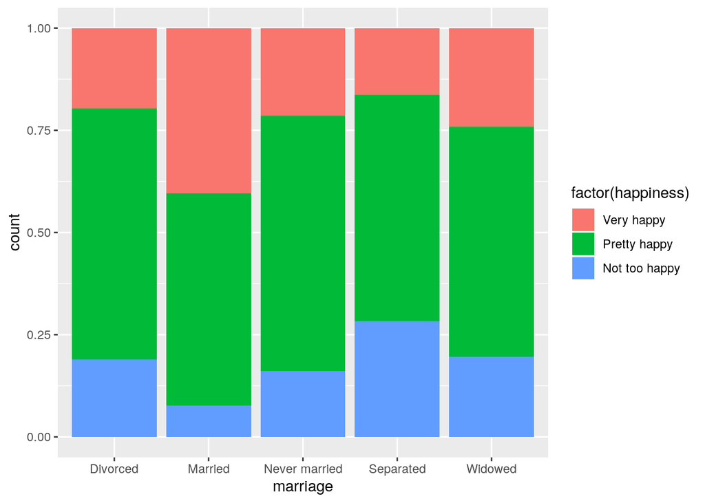

```r
dat %>%
  filter(marriage != "No answer", marriage != "NA") %>%
  ggplot(aes(x = marriage, fill = factor(happiness))) +
  geom_bar(position = "fill")
```

## Does the sex of the respondent affect the relationship you found in Q1?

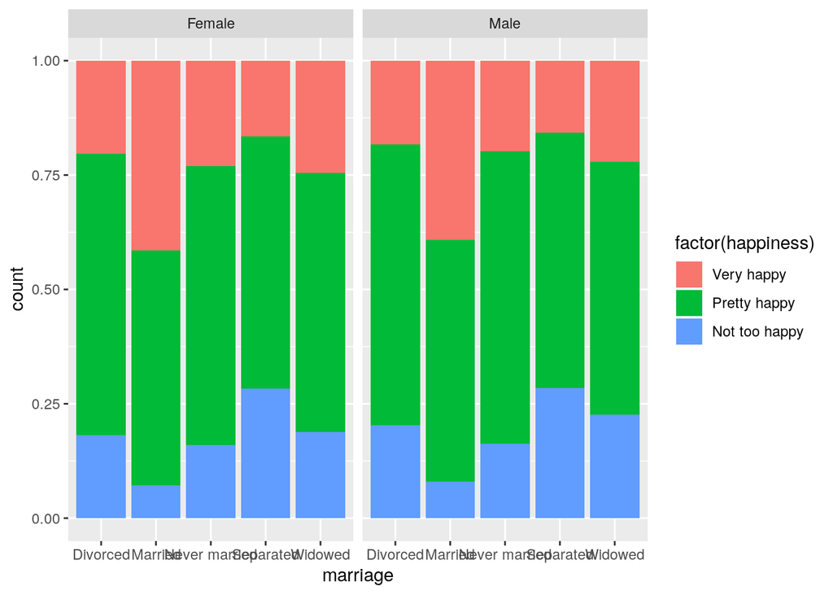

```r
dat %>%
  filter(marriage != "No answer", marriage != "NA") %>%
  ggplot(aes(x = marriage, fill = factor(happiness))) +
  geom_bar(position = "fill") +
  facet_grid(. ~ sex)
```

The graphs are nearly identical between Males and Females, so I do not believe the sex of the respondent has an effect on the relationship between marital status and happiness.

## How has the distribution of happiness changed over the years?

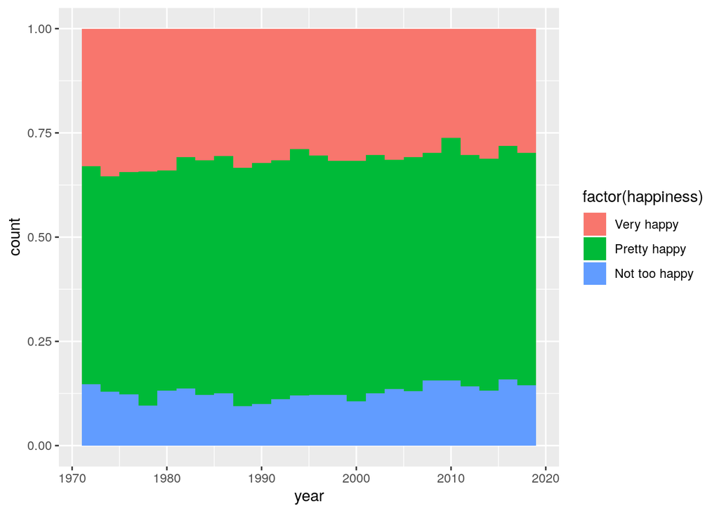

```r
dat %>%
  filter(year != "NA") %>%
  ggplot(aes(x = year, fill = factor(happiness))) +
  geom_bar(position = "fill", binwidth = 2)
```

There isn’t a ton of variance but it does appear that there’s been a slight incline in “Not too happy” responses over the last 30 years.

## Have political views become more polarized (i.e. more “Strong” republican/democrats in recent years) over time?

```r
unique(factor(dat$party))
```

```
## [1] Ind,near dem       Not str democrat   Independent        Strong democrat
## [5] Not str republican Ind,near rep       Strong republican  Other party
## [9] Don't know
## 9 Levels: Don't know Ind,near dem Ind,near rep ... Strong republican
```

Let’s relevel these quick to make them go in order in our graphic.

```r
party_levels <- c("Strong democrat", "Not str democrat", "Ind,near dem",
                  "Independent", "Ind,near rep", "Not str republican",
                  "Strong republican", "Other party", "Don't know")
levels(dat$party) <- party_levels
levels(dat$party)
```

```
## [1] "Strong democrat"    "Not str democrat"   "Ind,near dem"
## [4] "Independent"        "Ind,near rep"       "Not str republican"
## [7] "Strong republican"  "Other party"        "Don't know"
```

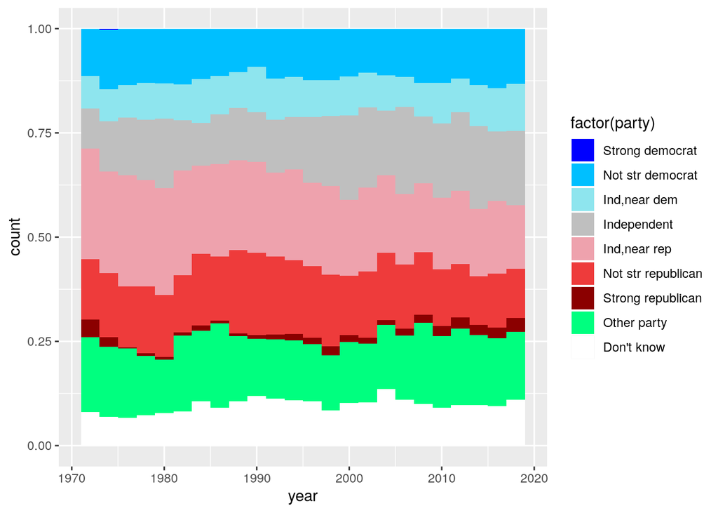

```r
dat %>%
  filter(party != "NA") %>%
  ggplot(aes(x = year, fill = factor(party))) +
  geom_bar(position = "fill", binwidth = 2) +
  scale_fill_manual(values = c("blue", "deepskyblue1", "cadetblue2",
                               "gray75", "lightpink2", "brown2",
                               "red4", "springgreen", "white"),
                    limits = party_levels)
```

The answer isn’t entirely clear. Depending on how you define “political polarization”, it could be yes or no. There’s been an overall decrease in republican identifying respondents since 1990 but a reasonable increase in “Strong” republican identifying respondents in that same period. Meanwhile there has been a slight increase in democrats. So this could be considered a “polarization”. On the other hand. There has been an overall decrease in republicans and increase in “other party” / “don’t know” respondents recently.

## How has the proportion of marital statuses change over time?

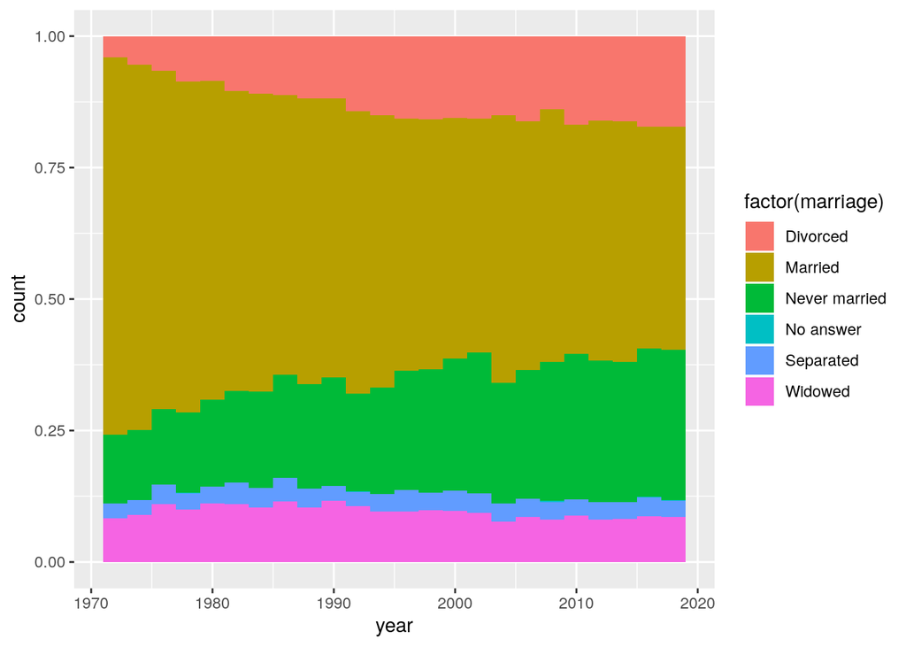

```r
dat %>%
  filter(year != "NA") %>%
  ggplot(aes(x = year, fill = factor(marriage))) +
  geom_bar(position = "fill", binwidth = 2)
```

There are a few pretty noticeable trends in the data. The proportion of married respondents has decreased a lot from 1970 to the present. There’s also been a big increase in respondents who were divorced or never married.

## How does the happiness of a respondent relate to the political party affiliation?

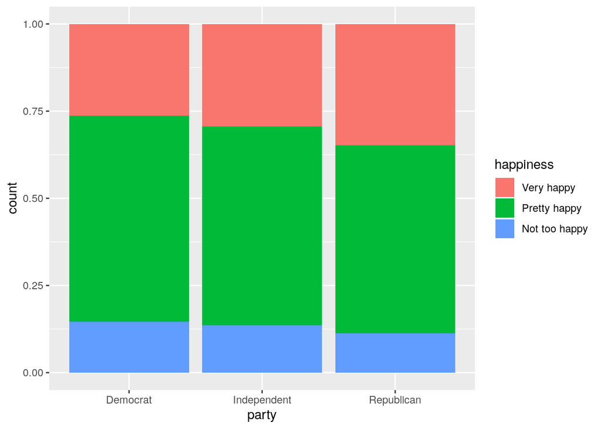

```r
  dat2 <- dat

  parties <- levels(dat2$party)
  levels(dat2$party)[levels(dat2$party) == 'Not str democrat' | levels(dat2$party) == 'Strong democrat'] <- 'Democrat'

  levels(dat2$party)[levels(dat2$party) == 'Not str republican' | levels(dat2$party) == 'Strong republican'] <- 'Republican'

  levels(dat2$party)[levels(dat2$party) == 'Don\'t know' | levels(dat2$party) == 'Other party'] <- 'Republican'

  levels(dat2$party)[levels(dat2$party) == 'Independent' | levels(dat2$party) == 'Ind,near dem' | levels(dat2$party) == 'Ind,near rep'] <- 'Independent'

  dat2 %>%
    ggplot(aes(x = party, fill = happiness)) + geom_bar(position = 'fill')
```

## Is political affiliation affected by education?

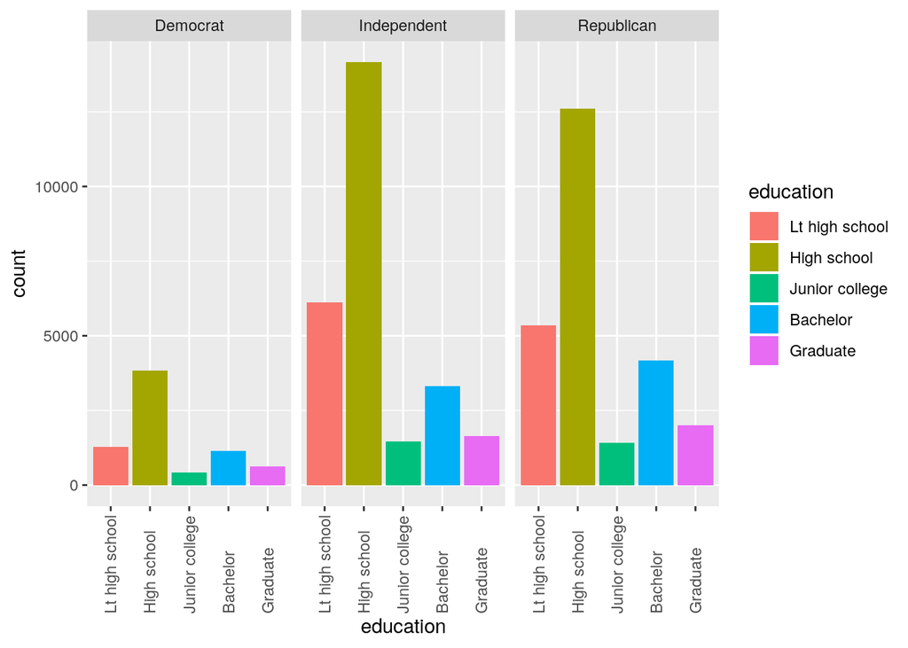

```r
  dat2$education <- factor(dat2$education, c('No answer', 'Don\'t know','Lt high school', 'High school','Junior college', 'Bachelor', 'Graduate'))

  filtered <- droplevels(dat2[dat2$education != 'No answer' & dat2$education != 'Don\'t know', ])

  filtered %>%
    ggplot(aes(x = education, fill = education)) + geom_bar() + facet_wrap(~party) + theme(axis.text.x = rotatedAxisElementText(90,'x'))
```

### How does the political affiliation affect place of residence?

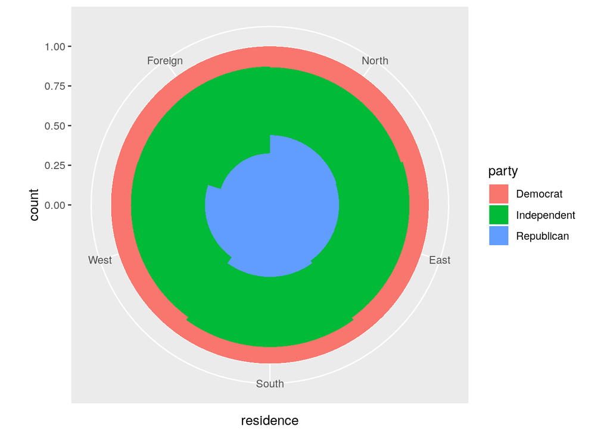

```r
  levels(dat2$residence)[levels(dat2$residence) == 'E. nor. central' | levels(dat2$residence) == 'W. nor. central'] <- 'North'

  levels(dat2$residence)[levels(dat2$residence) == 'New england' | levels(dat2$residence) == 'Middle atlantic' | levels(dat2$residence) == 'South atlantic'] <- 'East'

  levels(dat2$residence)[levels(dat2$residence) == 'E. sou. central' | levels(dat2$residence) == 'W. sou. central'] <- 'South'

  levels(dat2$residence)[levels(dat2$residence) == 'Mountain' | levels(dat2$residence) == 'Pacific' | levels(dat2$residence) == 'Ind,near rep'] <- 'West'

  dat2$residence <- factor(dat2$residence, c('North', 'East', 'South', 'West', 'Foreign'))

  dat2 %>%
    ggplot(aes(x = residence, fill = party)) + geom_bar(position = 'fill', width = 1) + coord_polar()
```